# ISLR2 Chapter 8: Applied Excercises #8 d & e p.363

Benham wasonga

2022-12-18

In the lab, a classification tree was applied to the Carseats data set after converting Sales into a qualitative response variable. Now we will seek to predict Sales using regression trees and related approaches, treating the response as a quantitative variable.

4. Use the bagging approach in order to analyze this data. What test MSE do you obtain? Use the importance() function to determine which variables are most important.

```r
library(ISLR2)
library (tree)
attach(Carseats)

## training set and a test set.
set.seed (1)
train <- sample (1: nrow(Carseats), nrow(Carseats)/2)  # 50:50 split ratio
training <- Carseats[train, ]
test <- Carseats[-train, ]

library(randomForest)
set.seed(2)
bag.carseats <- randomForest(Sales ~ ., data = training, mtry = 10, ntree = 500,
                             importance = TRUE)
yhat.bag <- predict(bag.carseats, newdata = test)
test.MSE <- mean((yhat.bag - test$Sales)^2)
test.MSE
```

```
## [1] 2.586535
```

```r
importance(bag.carseats)
```

```
##                %IncMSE IncNodePurity
## CompPrice   25.7444826     170.66690
## Income       4.7699543      90.24851
## Advertising 12.3934240     104.10313
## Population  -2.0752891      59.47636
## Price       55.2142251     505.28250
## ShelveLoc   47.2885836     376.66846
## Age         17.0744805     156.14233
## Education    2.1151607      45.21764
## Urban       -0.9618328       8.82340
## US           5.3624960      18.75708
```

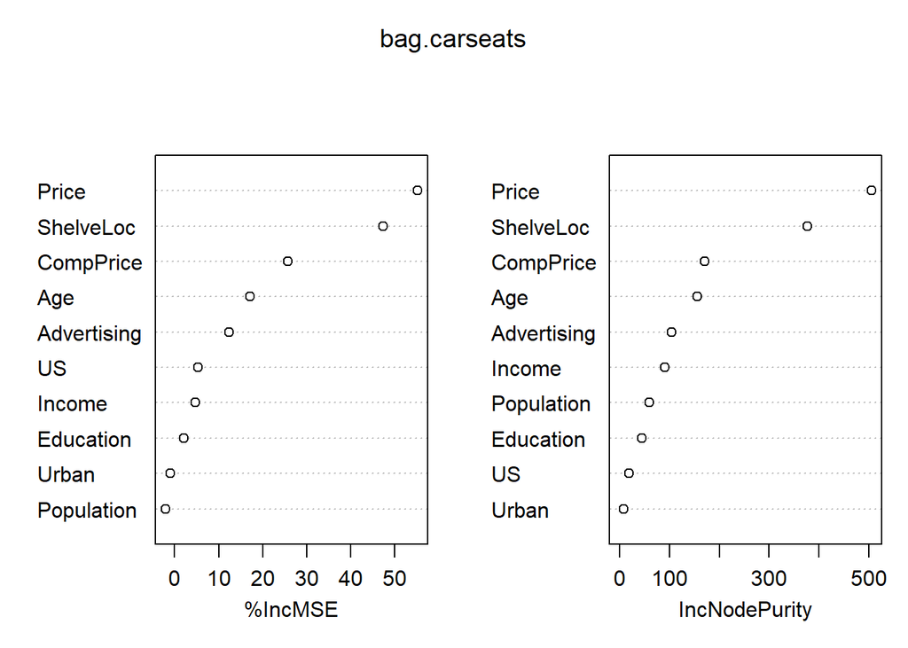

```r
varImpPlot (bag.carseats)
```

Comments: The test MSE obtained with bagging is 2.59, which is lower than the test MSE with the basic and pruned tree from parts b & c. The two most important predictors are Price, and ShelveLoc, with CompPrice coming a distant third.

5. Use random forests to analyze this data. What test MSE do you obtain? Use the importance() function to determine which variables are most important. Describe the effect of m, the number of variables considered at each split, on the error rate obtained

```r
set.seed(3)
Carseats.rf <- randomForest(Sales ~ ., data = training,
                            mtry = floor((ncol(Carseats)-1)/3),importance=TRUE)
yhat.rf <- predict(Carseats.rf, newdata = test)
test.MSE2 <- mean((yhat.rf - test$Sales)^2)
test.MSE2
```

```
## [1] 3.032044
```

```r
importance(Carseats.rf)
```

```
##                %IncMSE IncNodePurity
## CompPrice   13.9993490     156.96794
## Income       2.6778837     127.88614
## Advertising  8.1074652     110.09657
## Population  -1.3490283      99.84602
## Price       36.1585603     386.93759
## ShelveLoc   33.7173745     293.22070
## Age         12.4003364     172.59516
## Education    0.7386843      74.12860
## Urban        0.2239606      14.44513
## US           5.1556265      32.56098
```

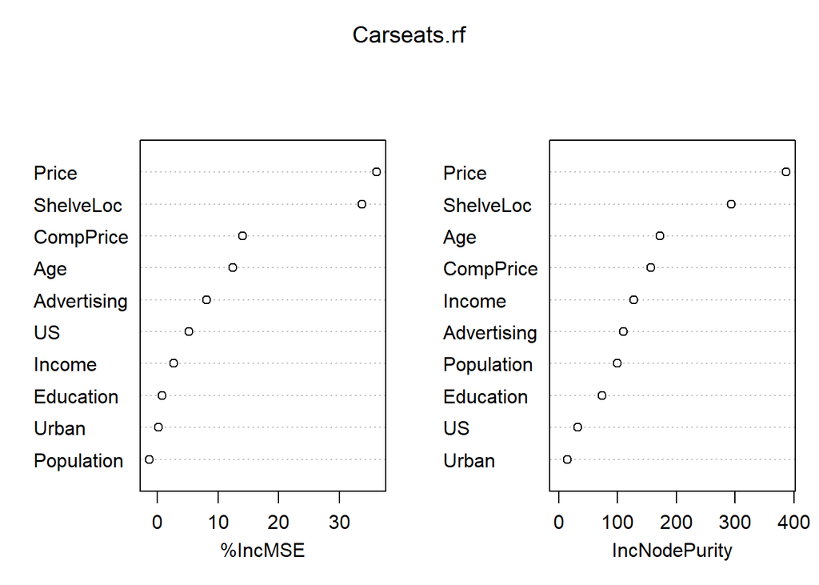

```r
varImpPlot (Carseats.rf)
```

Comments: When m = p/3 variables considered at each split, the test MSE obtained is 3.03, which is slightly higher than the test MSE obtained with bagging (2.59) but still lower than the test MSE obtained with the basic tree and pruned tree from parts b & c (4.92). The two most important predictors are Price, and ShelveLoc, similar to the result with bagging.